# Simple linear regression

## playbill

First we load the data.

```r
playbill <- read.csv('C:/Users/tonyg/Desktop/Academic/Grad/HUDM 5126/playbill.csv')
library(knitr)
```

Then we fit a linear model, $Y=\beta_0 + \beta_1 + e$ and summarize it in Table @ref(tab:pb-fit1).

```r
pb_fit1 <- lm(CurrentWeek ~ LastWeek, data = playbill)
kable(summary(pb_fit1)$coef,
      booktabs = TRUE,
      caption = "Coefficients our linear model.")
```

Coefficients our linear model.

|  | Estimate | Std. Error | t value | Pr(>\|t\|) |
| --- | --- | --- | --- | --- |
| (Intercept) | 6804.8860355 | 9929.3177930 | 0.6853327 | 0.5029432 |
| LastWeek | 0.9820815 | 0.0144272 | 68.0714024 | 0.0000000 |

### a

The confidence intervals for $\beta_1$ are given by

```r
confint(pb_fit1)[2, ]
```

```
##     2.5 %    97.5 %
## 0.9514971 1.0126658
```

As per the question, 1 seems like a plausible value given that returns are likely to be similar from one week to another (although exactly 1 is incredibly unlikely).

### b

We proceed to test the hypotheses
$$\begin{gather}
H_0:\beta_0 = 10000 \\
H_1:\beta_0 \neq 10000
\end{gather}$$

by running

```r
h_0 <- 10000
h_obs <- coef(pb_fit1)[[1]]
h_obs_se <- summary(pb_fit1)$coef[1, 2]
tobs <- (h_obs - h_0) / h_obs_se
(pobs <- 2 * pt(abs(tobs), nrow(playbill) - 2, lower.tail = FALSE))
```

```
## [1] 0.7517807
```

which leads us to accept the null hypothesis, $t(16) = -0.3217858$, $p = 0.7517807$.

### c

We make a prediction, including prediction interval, for a 400,000$ box office result in the previous week:

```r
predict(pb_fit1, data.frame(LastWeek = 400000), interval = "prediction")
```

```
##        fit      lwr      upr
## 1 399637.5 359832.8 439442.2
```

A prediction of 450,000$ is **not** feasible, given it is far outside our 95% prediction interval.

### d

This seems like an okay rule given the almost-perfect correlation from one week to another; however, looking at the residuals we see that there are at least three values that are predicted badly (Figure @ref(fig:pb-resid))

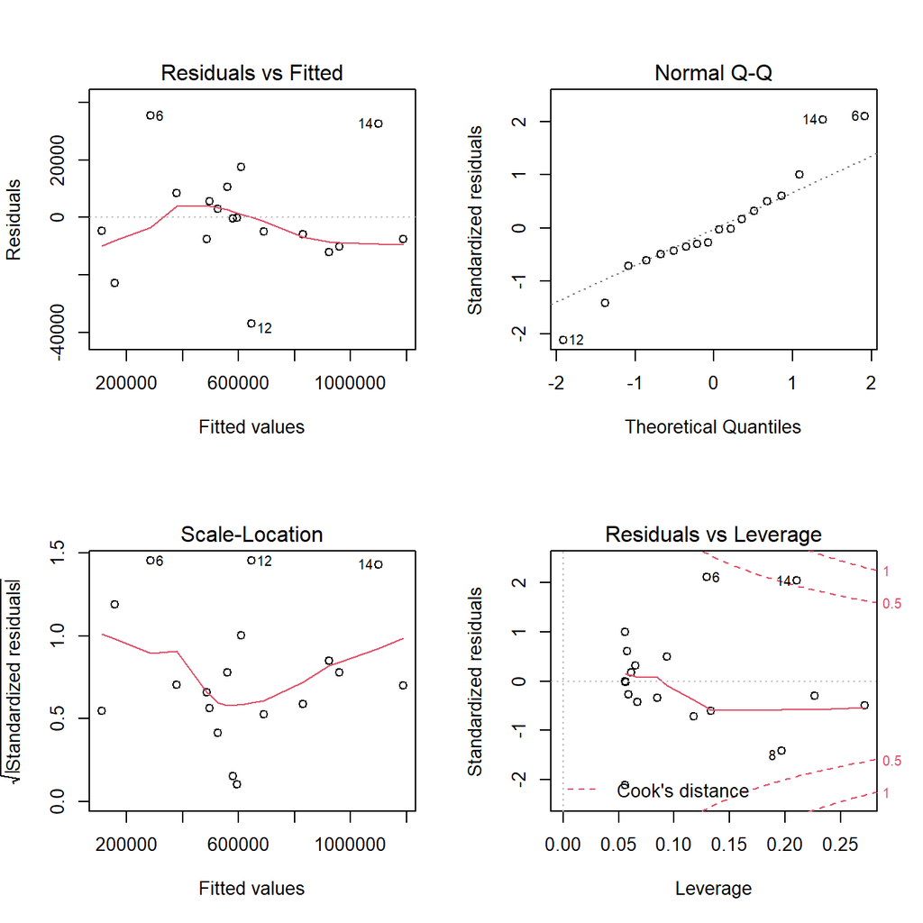

Residuals for our linear fit to the playbill data.

```r
par(mfrow = c(2, 2))
plot(pb_fit1)
```

## Indicators

```r
indicators <- read.table(file='C:/Users/tonyg/Desktop/Academic/Grad/HUDM 5126/indicators.txt',header = TRUE)
```

We begin by fitting our linear model to the data (Table @ref(tab:indicators-summary)).

```r
ind_fit1 <- lm(PriceChange ~ LoanPaymentsOverdue, data = indicators)
kable(summary(ind_fit1)$coef,
      booktabs = TRUE,
      caption = "Coefficients for our linear model to the indicators data set.")
```

Coefficients for our linear model to the indicators data set.

|  | Estimate | Std. Error | t value | Pr(>\|t\|) |
| --- | --- | --- | --- | --- |
| (Intercept) | 4.514494 | 3.3240193 | 1.358143 | 0.1932624 |
| LoanPaymentsOverdue | -2.248520 | 0.9033113 | -2.489197 | 0.0241941 |

### a

The 95% confidence interval for the $\beta_1$ estimate is, as before:

```r
confint(ind_fit1)[2, ]
```

```
##      2.5 %     97.5 %
## -4.1634543 -0.3335853
```

There is reason to believe that there is a negative trend.

### b

We now create a confidence interval for $\text{E}[Y|X=4]$:

```r
predict(ind_fit1, data.frame(LoanPaymentsOverdue = 4), interval = "confidence")
```

```
##         fit       lwr       upr
## 1 -4.479585 -6.648849 -2.310322
```

0% is not a reasonable estimate for $\text{E}[Y|X=4]$ since the 95% confidence limit is far below 0.

## Invoices

### a

We first find a 95% confidence level for $\beta_0$ using the output printed in the book.

```r
beta0 <- 0.6417099
beta0_se <- 0.122707
beta0_t <- 5.248
beta0_margin <- 1.96 * beta0_se
(beta0_95 <- c(beta0 - beta0_margin, beta0 + beta0_margin))
```

```
## [1] 0.4012042 0.8822156
```

Thus, the confidence limit it 0.4012042, 0.8822156

### b

We have the two-sided hypotheses
$$\begin{gathered}
H_0: \beta_1 = 0.01\\
H_1: \beta_1 \neq 0.01.
\end{gathered}$$

```r
beta <- 0.01
beta_obs_se <- 0.0008184
beta_obs <- 0.0112916
tval <- (beta - beta_obs) / beta_obs_se
(pobs <- 2 * pt(abs(tval), 30 - 1, lower.tail = FALSE))
```

```
## [1] 0.1253666
```

We fail to reject the null hypothesis, $t(29) = -1.5782014$, $p=0.1253666$. We cannot say that the true average processing time is significantly different from 0.01 hours.

### c

From the exercise description we have the expected value
$$\text{Time} = 0.6417099+\text{Invoices}\times 0.0112916$$
for the series. Next, we’ll predict the processing time for 130 invoices using the output given in the exercise.

```r
beta0 <- 0.6417099
beta1 <- 0.0112916
rse <- 0.3298
n <- 30
df <- n - 2
rss <- rse^2 * df
mse <- rss / n
time <- beta0 + beta1 * 130
err <- qt(0.975, 28) * sqrt(mse) * sqrt(1 + 1 / n) # since x0 = xbar
upr <- time + err
lwr <- time - err
```

Which results in a point estimate of 2.1096179, 95% CI: $[1.446172, 2.7730638]$.